# Package Installation

```python
# Install libraries within Jupyter Notebook
!pip install graphviz
!pip install pydotplus
!conda install python-graphviz -y

# If there is any other library installation error, just add another !pip install libraryName above
```

[output not shown]

# Notebook Styling: Please do not edit this.

```python
import IPython
import graphviz
import pydotplus
from io import StringIO
import matplotlib.pyplot as plt

from IPython.display import display, HTML, SVG, Image
from graphviz import Source

plt.style.use('seaborn-paper')
plt.rcParams['figure.figsize'] = [10, 6] ## plot size
plt.rcParams['axes.linewidth'] = 2.0 #set the value globally

## notebook style and settings
display(HTML("<style>.container { width:90% !important; }</style>"))
display(HTML("<style>.output_png { display: table-cell; text-align: center; vertical-align: middle; } </style>"))
display(HTML("<style>.MathJax {font-size: 100%;}</style>"))
```

# 1. Quick intro to Python

We will start with a quick introduction to python programming languages and discuss some components that we will be using for the rest of the semester. At the end of this notebook, there is a supplement video that goes over the same concepts in slightly more depth. You are advised to go through that material, understand this notebook, and start tinkering with it (in the same order).

## 1.1 Python Libraries

Python has a huge set of built-in and open-source libraries that we can use to speed-up almost everything as we'll see in this semester. We will start with a few built-in libraries before moving on to some popular open-source libraries.

All Built-in Python Libraries: https://docs.python.org/3/library/

```python
# How to import libraries
import os
import sys

#### NOTE: We can also import them by using an alias for the library name e.g import os as o
#### NOTE: Each library contains a huge number of functions which can be used in the following format: libraryName.FunctionName(). You'll learn about functions in a few cells.
```

## 1.2 Variables

Variables are containers for storing different types of data values such as numbers, strings, characters etc. In python, a variable is always assigned a value whenever it is declared. Here are a few examples.

```python
variableOne = 123 # this is a number. In programming, we call this an "integer".
variableTwo = 12.3 # this is also a number but in programming, we call it a "float".
variableThree = "IntroToPython"
variableFour = 'IntroToPython' # both variable two and three are strings. We can write a string with single or double quotes.

# To print the value of a variable, we can use something called print() in python.
print("The value of variable one is:", variableOne)
print("The value of variable two is:", variableTwo)
print("The value of variable three is:", variableThree)
print("The value of variable four is:", variableFour)
```

```
The value of variable one is: 123
The value of variable two is: 12.3
The value of variable three is: IntroToPython
The value of variable four is: IntroToPython
```

### How to find a variable type?

In order to find the type of a variable, we can use something called "type" in python.

```python
print("The type of variable one is:", type(variableOne))
print("The type of variable two is:", type(variableTwo))
print("The type of variable three is:", type(variableThree))
print("The type of variable four is:", type(variableFour))
```

```
The type of variable one is: <class 'int'>
The type of variable two is: <class 'float'>
The type of variable three is: <class 'str'>
The type of variable four is: <class 'str'>
```

## 1.3 Functions

Functions are one of the most fundamental basic blocks of any programming languages. A function is a piece of code that can take in an input, do some computation on it, and return an output. In the above cell, we just saw an example of the **print(string)** function that takes as a string and prints it out. We will make extensive use of functions throughout this semester.

### Example 1: $f(x) = x^2$

Functions are used not just in programming but in plenty of other subjects as well. Consider for example a square function $f(x) = x^2$. This function takes as input a number, computes its square, and outputs it. Now that we have a basic understanding of a function, let us write some.

```python
def square(x):
    squareOfX = x * x # * is an operator for multiplication.
    return squareOfX
```

That's it! "sqaure" is the name of the function we just created and it will only accept one input (x). To use this function, we simply use its name and provide a value in place of x:

```python
square(x = 12) # You can also run square(12)
```

```
144
```

We can use the output of a function as input in another function. Below, we are using the output of the function we created (square) as input to a Python function (print):

```python
x = 12 # You can change this value
xSquare = square(x)
print("Square of x is: ", xSquare)
```

```
Square of x is:  144
```

To help us (and other collaborators) to track what new functions do and what type and how many inputs and what type and how many outputs they expect/ provide, we can add the description of the function inside the function. The description does not change anything in the function, it just documents the details related to the function. To add the descriptions, we use three quotation marks (""") to start the description and three quotation marks (""") to end the description. Below, we just added the description to our toy function square:

```python
def square(x):
    """
    Each function is defined by a keyword "def" followed by the function name "square".

    Input:
    A function can take multiple inputs inside the brackets (x, y, ...)

    Output:
    To output something from a function, we use a keyword "return" with the variable that we want to output
    """

    squareOfX = x * x # * is an operator for multiplication.
    return squareOfX

x = 12 # You can change this value
xSquare = square(x)
print("Square of x is: ", xSquare)
```

```
Square of x is:  144
```

You can see that the function works the same way. But now we can see what is the description of the function using help:

```python
help(square)
```

```
Help on function square in module __main__:

square(x)
    Each function is defined by a keyword "def" followed by the function name "square".

    Input:
    A function can take multiple inputs inside the brackets (x, y, ...)

    Output:
    To output something from a function, we use a keyword "return" with the variable that we want to output
```

Similarly, if you need to know more about the details of a function, you can use help. Below, we ask for the details of function print:

```python
help(print)
```

```
Help on built-in function print in module builtins:

print(...)
    print(value, ..., sep=' ', end='\n', file=sys.stdout, flush=False)

    Prints the values to a stream, or to sys.stdout by default.
    Optional keyword arguments:
    file:  a file-like object (stream); defaults to the current sys.stdout.
    sep:   string inserted between values, default a space.
    end:   string appended after the last value, default a newline.
    flush: whether to forcibly flush the stream.
```

### Example 2: $f(x, y) = x + y$

```python
def sum(x, y):
    """
    Each function is defined by a keyword "def" followed by the function name "sum".

    Input:
    A function can take multiple inputs inside the brackets (x, y, ...)

    Output:
    To output something from a function, we use a keyword "return" with the variable that we want to output
    """

    sumOfNumbers = x + y # + is an operator for addition
    return sumOfNumbers

x = 12 # You can change this value
y = 18
numbersSum = sum(x, y) # IMPORTANT NOTE: Always remember that the name of the function should be different from the name of all the variables you have defined. Same goes for the variables. Everything should have a unique name
print("Sum of x and y is: ", numbersSum)
```

```
Sum of x and y is:  30
```

### Example 3: $f(x, y) = x + y, x - y$

Functions can also return multiple values by separating them with commas as shown in the following example

```python
def sumAndDifference(x, y):
    sumOfNumbers = x + y # + is an operator for addition
    difference = x - y
    return sumOfNumbers, difference # Returning multiple values

x = 12 # You can change this value
y = 18
numbersSum, numbersDifference = sumAndDifference(x, y)
print("Sum of x and y is: ", numbersSum)
print("Difference of x and y is: ", numbersDifference)
```

```
Sum of x and y is:  30
Difference of x and y is:  -6
```

If we do not want to return anything from a function, we simply don't add any return statements in the function.

## 1.4 Lists

In order to gather multiple variables in a single place, we use what we call a "list" in python. A single list can contain different types of variables. Lists are extremely useful for many tasks as we'll see in the coming sections.

Lists are defined similar to variables but instead of one value, we can add multiple values in a list using [] brackets.

```python
listOne = [1, 2, 3] # All integers
listTwo = [1, 2, "Three"] # Two integers, one string
print("List One is: ", listOne)
print("List Two is: ", listTwo)


# Indexing in lists. Instead of printing an entire list, we can also print individual items using what we call indexing.
print("First item of list one is: ", listOne[0]) # Print the first item of listOne. Remember, indexing starts from 0.
print("Third item of list two is: ", listTwo[2]) # Print the third item of listTwo

# We can also use reverse indexing by using negative numbers as indexes
print("Last item of list one is: ", listOne[-1]) # Print the last item of listOne. Remember, reverse indexing starts from -1.
print("Second Last item of list two is: ", listTwo[-2]) # Print the second last item of listTwo
```

```
List One is:  [1, 2, 3]
List Two is:  [1, 2, 'Three']
First item of list one is:  1
Third item of list two is:  Three
Last item of list one is:  3
Second Last item of list two is:  2
```

## 1.5 If-Else Statements

When we want to condition what we do, we use if-else statements. This is an extremely important and useful concept in programming and everyone needs to know about it. Python makes it very easy to use if-else statements. Let us take a look at a few examples.

```python
# Example with strings
case = "Case1"
if case == "Case1":
    print("We are at Case1 right now.")
else:
    print("We are studying some other case.")


# Example with integers and operators
numberOne = 1
numberTwo = 2
numberSum = numberOne + numberTwo
if numberSum > 5:
    print("Sum of numbers is greater than 5")
else:
    print("Sum of numbers is less than 5")
```

```
We are at Case1 right now.
Sum of numbers is less than 5
```

## 1.6 Loops

When we want to repeat a task many times, we use what we call loops in Python. Python again makes it very easy and intuitive to write loops. Let us take a look at some tasks that can be done with loops.

```python
print("Loops with lists...")
ourList = [1,2,3,4,5]
for item in ourList:
    print(item)

# We can also write the above loop using a function called range that creates a list from 0-n
print("Loops with range function...")
for item in range(0, 6):
    print(item)
```

```
Loops with lists...
1
2
3
4
5
Loops with range function...
0
1
2
3
4
5
```

## 1.7 File Handling and Data Loading

File handling is the last concept we need to understand in order to dive into the machine learning stuff. Most of the time, the data you need for a machine learning algorithm comes from a file. Reading and writing files is very easy in python and can be done within a few lines. Let us load our data set into a list.

```python
# We will read our data into a list that will contain each line as a single item. The number of items will be equal to the number of rows in the data set.
data = open("Data/RP_SP_All.tsv", "r").readlines()

# Let us print the first line of the data. The first line of our data set is the name of each feature separated by a comma
print("Printing feature names...")
print(data[0])

# Let us print the second line. Second line onwards is the data values for each feature
print("Printing second line of the data set...")
print(data[1])
```

```
Printing feature names...
PlayerID	PlayerName	PlayerYear	IsRP	ORG=ARI	ORG=ATL	ORG=BAL	ORG=BOS	ORG=CHI	ORG=CIN	ORG=CLE	ORG=COL	ORG=CWS	ORG=DET	ORG=HOU	ORG=KC	ORG=LA	ORG=LAA	ORG=MIA	ORG=MIL	ORG=MIN	ORG=NY	ORG=NYY	ORG=OAK	ORG=PHI	ORG=PIT	ORG=SD	ORG=SEA	ORG=SF	ORG=STL	ORG=TB	ORG=TEX	ORG=TOR	ORG=WSH	PY LRD Sal	TE=1	TE=2	TE=3+	MLS…

Printing second line of the data set...
228634	"Clippard, Tyler"	2014	1	0	0	0	0	0	0	0	0	0	0	0	0	0	0	0	0	0	0	0	1	0	0	0	0	0	0	0	0	0	0	5875000	0	0	1	5.148	70.1	2.18	75	0	7	4	0	1.5	10	3.57	10.49	0.188	0.257	0.284	0.541	70.1	2.18	75	0	7	4	0	1.5	10	3.57	10.49	0.188	0.257	0.284	0.541	1
```

As we can see, **readlines()** gives us entire lines as single items. Each line is one long string which we cannot feed to any machine learning algorithm. To do that, we have to convert each line into a list of integers/floats which we can then input to our machine learning models. Let us do that within a few lines.

```python
features = []
labels = []

# For each line skipping the first line (columns)
for line in data[1:]:

    # Strip the last endline character and split the string by commas. split() gives us a list after splitting the string by the comma.
    lineValues = line.strip("\n").split("\t")[2:] # Skip the first two columns since they are for informational purposes only

    # After splitting, the values are usually still in strings. We need to convert them into numeric values using either float(value) or integer(value)
    lineValues = [float(value.replace(',','')) if value != '' else 0 for value in lineValues] # Adding multiple things in a single list is called list comprehension. You don't need to learn this but do try to understand what's written here.

    # Add into features list and labels
    features.append(lineValues[0:len(lineValues) - 1]) # Everything but the last value since that's the label
    labels.append(lineValues[-1]) # Or we could have written lineValues[len(lineValues) - 1]

print("Number of total instances", len(labels))
print("Label distribution of 0 and 1 respectively", round(labels.count(0) / len(labels), 2), round(labels.count(1) / len(labels), 2))
```

```
Number of total instances 754
Label distribution of 0 and 1 respectively 0.69 0.31
```

## 1.8 File Handling with Pandas

Almost all the time, we never do anything with raw python. There are python libraries for doing every task in a machine learning pipeline. We will always use these libraries to make it easy and compact to write code. Pandas is a library for handling all types of files. It provides functions to do long tasks in a few lines. Let us do what we did in the above two sections with pandas.

```python
# Importing pandas.
import pandas as pd

# Read more: https://pandas.pydata.org/
```

Note: We could have written "import pandas" but then we would have to use pandas.functionName everywhere. With "pandas as pd", we can use pd.functionName. This is just a convention that every ML person follows.

We will use what we call a **DataFrame** in pandas which is a 2-dimensional labeled data structure with columns of potentially different types. You can think of it like a spreadsheet or SQL table.

[figure not shown]

```python
df = pd.read_csv("Data/RP_SP_All.tsv", "\t") # Read a csv file using the function read_csv
df = df.dropna() # Drop any null values using the function dropna
display(df) # Display the data
```

|  | PlayerID | PlayerName | PlayerYear | IsRP | ORG=ARI | ORG=ATL | ORG=BAL | ORG=BOS | ORG=CHI | ORG=CIN | ... | DL.1 | WAR.1 | WS.1 | SO/BB.1 | SO/9.1 | AVG.1 | OBP.1 | SLG.1 | OPS.1 | Filed |
| --- | --- | --- | --- | --- | --- | --- | --- | --- | --- | --- | --- | --- | --- | --- | --- | --- | --- | --- | --- | --- | --- |
| 0 | 228634 | Clippard, Tyler | 2014 | 1 | 0 | 0 | 0 | 0 | 0 | 0 | ... | 0 | 1.5 | 10 | 3.57 | 10.49 | 0.188 | 0.257 | 0.284 | 0.541 | 1 |
| 1 | 342281 | Holland, Greg | 2014 | 1 | 0 | 0 | 0 | 0 | 0 | 0 | ... | 21 | 9.5 | 53 | 3.85 | 12.47 | 0.197 | 0.269 | 0.290 | 0.559 | 1 |
| 2 | 359301 | Chapman, Aroldis | 2014 | 1 | 0 | 0 | 0 | 0 | 0 | 1 | ... | 80 | 8.6 | 52 | 3.52 | 15.32 | 0.147 | 0.261 | 0.224 | 0.485 | 1 |
| 3 | 305150 | Jansen, Kenley | 2014 | 1 | 0 | 0 | 0 | 0 | 0 | 0 | ... | 49 | 8.3 | 54 | 4.48 | 14.02 | 0.174 | 0.252 | 0.270 | 0.522 | 0 |
| 4 | 338893 | Cishek, Steven | 2014 | 1 | 0 | 0 | 0 | 0 | 0 | 0 | ... | 0 | 5.3 | 41 | 3.09 | 9.92 | 0.222 | 0.297 | 0.315 | 0.612 | 0 |
| ... | ... | ... | ... | ... | ... | ... | ... | ... | ... | ... | ... | ... | ... | ... | ... | ... | ... | ... | ... | ... | ... |
| 749 | 143726 | Hernandez, Runelvys | 2005 | 0 | 0 | 0 | 0 | 0 | 0 | 0 | ... | 296 | 3.3 | 16 | 1.40 | 5.00 | 0.268 | 0.340 | 0.429 | 0.769 | 0 |
| 750 | 600170 | Small, Aaron | 2005 | 0 | 0 | 0 | 0 | 0 | 0 | 0 | ... | 0 | 1.2 | 17 | 1.26 | 4.84 | 0.292 | 0.365 | 0.433 | 0.797 | 1 |
| 751 | 136675 | Downs, Scott | 2005 | 0 | 0 | 0 | 0 | 0 | 0 | 0 | ... | 308 | 2.2 | 8 | 1.80 | 6.30 | 0.291 | 0.360 | 0.470 | 0.830 | 0 |
| 752 | 123760 | Day, Zach | 2005 | 0 | 0 | 0 | 0 | 0 | 0 | 0 | ... | 199 | 2.5 | 18 | 1.13 | 4.60 | 0.265 | 0.348 | 0.409 | 0.758 | 0 |
| 753 | 142796 | Kim, Sun Woo | 2005 | 0 | 0 | 0 | 0 | 0 | 0 | 0 | ... | 0 | 1.7 | 13 | 1.71 | 5.65 | 0.291 | 0.361 | 0.451 | 0.811 | 1 |

753 rows × 70 columns

```python
df.info() # This gives us some information about the number of non-null observations and column types.
```

```
<class 'pandas.core.frame.DataFrame'>
Int64Index: 753 entries, 0 to 753
Data columns (total 70 columns):
 #   Column      Non-Null Count  Dtype
---  ------      --------------  -----
 0   PlayerID    753 non-null    int64
 1   PlayerName  753 non-null    object
 2   PlayerYear  753 non-null    int64
 3   IsRP        753 non-null    int64
 4   ORG=ARI     753 non-null    int64
 5   ORG=ATL     753 non-null    int64
 6   ORG=BAL     753 non-null    int64
 7   ORG=BOS     753 non-null    int64
 8   ORG=CHI     753 non-null    int64
 9   ORG=CIN     753 non-null    int64
```

[output cut: 62 more lines]

```python
df.columns # Lists the columns in df
```

```
Index(['PlayerID', 'PlayerName', 'PlayerYear', 'IsRP', 'ORG=ARI', 'ORG=ATL',
       'ORG=BAL', 'ORG=BOS', 'ORG=CHI', 'ORG=CIN', 'ORG=CLE', 'ORG=COL',
       'ORG=CWS', 'ORG=DET', 'ORG=HOU', 'ORG=KC', 'ORG=LA', 'ORG=LAA',
       'ORG=MIA', 'ORG=MIL', 'ORG=MIN', 'ORG=NY', 'ORG=NYY', 'ORG=OAK',
       'ORG=PHI', 'ORG=PIT', 'ORG=SD', 'ORG=SEA', 'ORG=SF', 'ORG=STL',
       'ORG=TB', 'ORG=TEX', 'ORG=TOR', 'ORG=WSH', 'PY LRD Sal', 'TE=1', 'TE=2',
       'TE=3+', 'MLS', 'IP', 'ERA', 'G', 'GS', 'W', 'L', 'DL', 'WAR', 'WS',
       'SO/BB', 'SO/9', 'AVG', 'OBP', 'SLG', 'OPS', 'IP.1', 'ERA.1', 'G.1',
       'GS.1', 'W.1', 'L.1', 'DL.1', 'WAR.1', 'WS.1', 'SO/BB.1', 'SO/9.1',
       'AVG.1', 'OBP.1', 'SLG.1', 'OPS.1', 'Filed'],
      dtype='object')
```

We can now decide which columns we want to use as predictors in our model. Let's use all of them except 'PlayerID', 'PlayerName' (these two are unique identifiers and therefore have no predictive power), and 'Filed' which is our target variable:

```python
preds = [column for column in df.columns if column not in ('PlayerID', 'PlayerName', 'Filed')]
```

Now we separate predictors and target variable:

```python
X = df[preds]
y = df['Filed']
```

# 2. Machine Learning with ScikitLearn

Scikit-learn provides a very high level abstraction over a large number of machine learning methods. It provides ML algorithms as functions that take as input the data and learn patterns in it. All we need are two things:

1. Feature List where each item in the list is another list containing features for a single row.
2. Label List where each item is the label

Here is how ML pipelines work in Scikit-learn.

[figure not shown]

#### Machine Learning Flow in ScikitLearn

More Information: https://scikit-learn.org/stable/

## 2.1 Importing Scikit Learn Functions

We can import functions directly from a library by using the keyword **"from libraryName import Function"**. Some functions can contain functions within them which we call "Classes" in programming. We won't discuss classes here but don't be surprised if you see something like functionName.functionName.functionName(parameters).

```python
# Tree function is used for visualizing decision tree
from sklearn import tree

# Importing function that can be used to calculate different metrics such as accuracy, precision, recall.
from sklearn.metrics import *

# Importing Decision Tree Algorithm
from sklearn.tree import DecisionTreeClassifier

# Importing function that can split a dataset into training and testing set
from sklearn.model_selection import train_test_split
```

## 2.2 Data Splitting into Training and Testing

We usually split our data into training and testing sets with 80:20 ratio. This means our data is randomly split into 80% training set and 20% testing set. We use the training data to train our models and test them on testing set. Validation set is also used to finetune parameters but we won't discuss it here. It will be discussed in the upcoming notebooks.

```python
# Determine the data split percentage. 0.8 means 80% goes to test data.
trainData, testData, trainLabels, testLabels = train_test_split(X, y, train_size = .8)

print("Total Data Rows: ", len(X))
print("Train Data Rows: ", len(trainData))
print("Test Data Rows: ", len(testData))
```

```
Total Data Rows:  753
Train Data Rows:  602
Test Data Rows:  151
```

## 2.3 Training Machine Learning Algorithms

```python
# Set parameters for the decision tree algorithm
MAXIMUM_TREE_DEPTH = 10 # Maximum depth of the tree that you are training
WEIGHT_0_LABEL = 1 # Weight for "Not Filed" label. Since the data is imbalanced, using weights for each class will address this in the model
WEIGHT_1_LABEL = 3 # Weight for "Filed" label.

# Create an instance of the decision tree algorithm. You can consider "classifier" as a function that is going to get training data and train a decision tree algorithm. Next, it will take any test data and make a prediction based on the learned decision tree
classifier = DecisionTreeClassifier(max_depth = MAXIMUM_TREE_DEPTH, class_weight = {0:WEIGHT_0_LABEL, 1:WEIGHT_1_LABEL}, random_state = 6)

# Train the decision tree model using the function .fit
classifier.fit(trainData, trainLabels)
```

```
DecisionTreeClassifier(class_weight={0: 1, 1: 3}, max_depth=10, random_state=6)
```

## 2.4 Evaluating Machine Learning Algorithms

We can use the following custom function to calculate a variety of model performance metrics (please do not change the function below):

```python
def calculateMetricsAndPrint(predictions, predictionsProbabilities, actualLabels):
    predictionsProbabilities = [item[1] for item in predictionsProbabilities]

    accuracy = accuracy_score(actualLabels, predictions) * 100
    precisionNegative = precision_score(actualLabels, predictions, average = None)[0] * 100
    precisionPositive = precision_score(actualLabels, predictions, average = None)[1] * 100
    recallNegative = recall_score(actualLabels, predictions, average = None)[0] * 100
    recallPositive = recall_score(actualLabels, predictions, average = None)[1] * 100
    auc = roc_auc_score(actualLabels, predictionsProbabilities) * 100

    print("Accuracy: %.2f\nPrecisionNegative: %.2f\nPrecisionPositive: %.2f\nRecallNegative: %.2f\nRecallPositive: %.2f\nAUC Score: %.2f\n" %
          (accuracy, precisionNegative, precisionPositive, recallNegative, recallPositive, auc))
```

```python
# Predict on test data
predictions = classifier.predict(testData) # This will give binary labels e.g 0/1
predictionProbabilities = classifier.predict_proba(testData) # This will give prediction probabilities for both labels e.g [0.3, 0.7] meaning 0.3 probability for 0 and 0.7 for 1.

# Calculate metrics on test set and display them
calculateMetricsAndPrint(predictions, predictionProbabilities, testLabels)
```

```
Accuracy: 51.66
PrecisionNegative: 73.53
PrecisionPositive: 33.73
RecallNegative: 47.62
RecallPositive: 60.87
AUC Score: 55.01
```

We can use the following function to create the ROC curve (please do not change the function):

```python
def plot_roc_curve(fpr, tpr):
    plt.plot(fpr, tpr, color='orange', label='ROC')
    plt.plot([0, 1], [0, 1], color='darkblue', linestyle='--')
    plt.xlabel('False Positive Rate')
    plt.ylabel('True Positive Rate')
    plt.title('Receiver Operating Characteristic (ROC) Curve')
    plt.legend()
    plt.show()
```

Now we use the function to create the curve:

```
AUC Score = 55.010
```

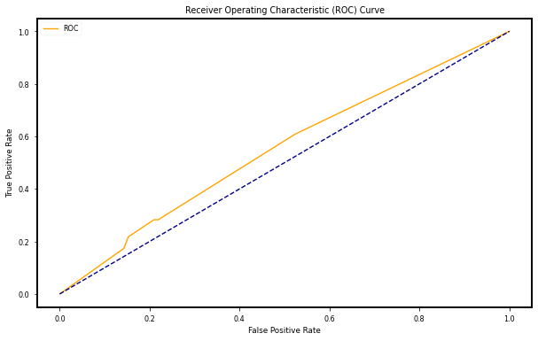

```python
# keep probabilities for the positive outcome only
pos_probs = predictionProbabilities[:, 1]

fpr, tpr, thresholds = roc_curve(testLabels, pos_probs, pos_label = 1)

# calculate scores
lr_auc = roc_auc_score(testLabels, pos_probs)
print('AUC Score = %.3f' % (lr_auc * 100))
plot_roc_curve(fpr, tpr)
```

## 2.5 Visualizing Decision Tree

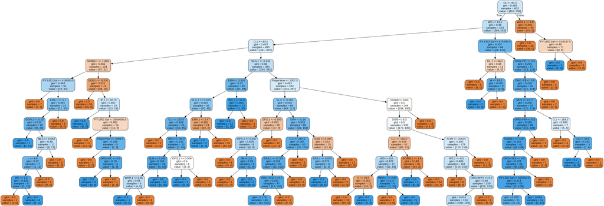

```python
dot_data = StringIO()
tree.export_graphviz(classifier, out_file=dot_data,
                                    feature_names=preds,
                                    filled=True, rounded=True)
graph = pydotplus.graph_from_dot_data(dot_data.getvalue())
display(Image(graph.create_png()))
```

# 3. Supplement Material

```python
IPython.display.IFrame('https://www.youtube.com/embed/1QDvkkdyGw0', 1200, 600)
```

[video not shown]